# Logistic_regression

# Social Networks Ads

### 1. Download the Social_Network_Ads dataset and import it into R

```r
df <- read.csv("Social_Network_Ads.csv", header=TRUE, sep=",")
df
```

| User.ID | Gender | Age | EstimatedSalary | Purchased |
| --- | --- | --- | --- | --- |
| 15624510 | Male | 19 | 19000 | 0 |
| 15810944 | Male | 35 | 20000 | 0 |
| 15668575 | Female | 26 | 43000 | 0 |
| 15603246 | Female | 27 | 57000 | 0 |
| 15804002 | Male | 19 | 76000 | 0 |
| 15728773 | Male | 27 | 58000 | 0 |
| 15598044 | Female | 27 | 84000 | 0 |
| 15694829 | Female | 32 | 150000 | 1 |
| 15600575 | Male | 25 | 33000 | 0 |
| 15727311 | Female | 35 | 65000 | 0 |

[output cut: 390 more lines]

### 2. Download the Social_Network_Ads dataset and import it into R

#### General analysis

```r
summary(df)
```

```
    User.ID            Gender               Age        EstimatedSalary    Purchased
 Min.   :15566689   Length:400         Min.   :18.00   Min.   : 15000   Min.   :0.0000
 1st Qu.:15626764   Class :character   1st Qu.:29.75   1st Qu.: 43000   1st Qu.:0.0000
 Median :15694342   Mode  :character   Median :37.00   Median : 70000   Median :0.0000
 Mean   :15691540                      Mean   :37.66   Mean   : 69743   Mean   :0.3575
 3rd Qu.:15750363                      3rd Qu.:46.00   3rd Qu.: 88000   3rd Qu.:1.0000
 Max.   :15815236                      Max.   :60.00   Max.   :150000   Max.   :1.0000
```

```r
str(df)
```

```
'data.frame':   400 obs. of  5 variables:
 $ User.ID        : int  15624510 15810944 15668575 15603246 15804002 15728773 15598044 15694829 15600575 15727311 ...
 $ Gender         : chr  "Male" "Male" "Female" "Female" ...
 $ Age            : num  19 35 26 27 19 27 27 32 25 35 ...
 $ EstimatedSalary: num  19000 20000 43000 57000 76000 58000 84000 150000 33000 65000 ...
 $ Purchased      : int  0 0 0 0 0 0 0 1 0 0 ...
```

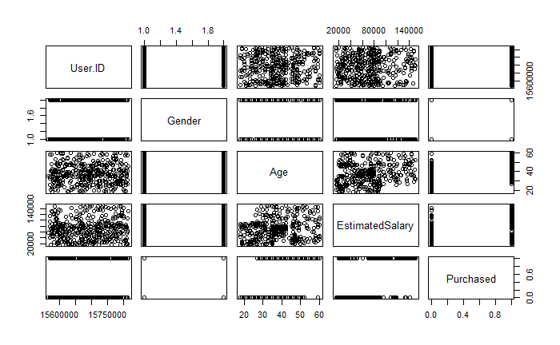

```r
plot(df)
```

#### Quantitative features analysis

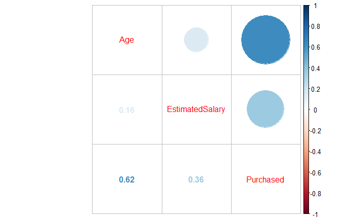

```r
library(corrplot)
M = cor(df[c("Age","EstimatedSalary", "Purchased")])
corrplot.mixed(M)
```

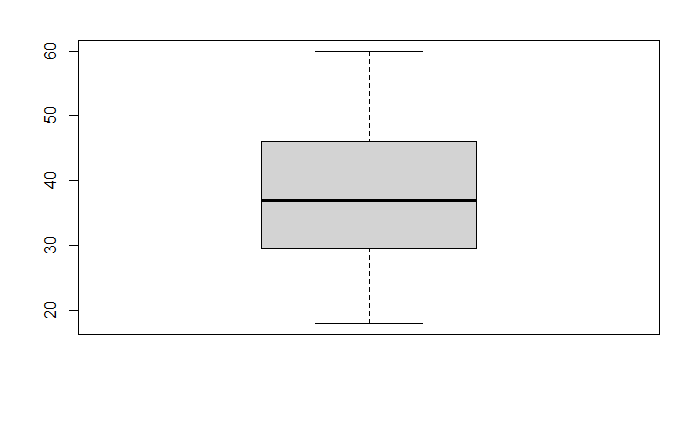

```r
boxplot(df$Age)
```

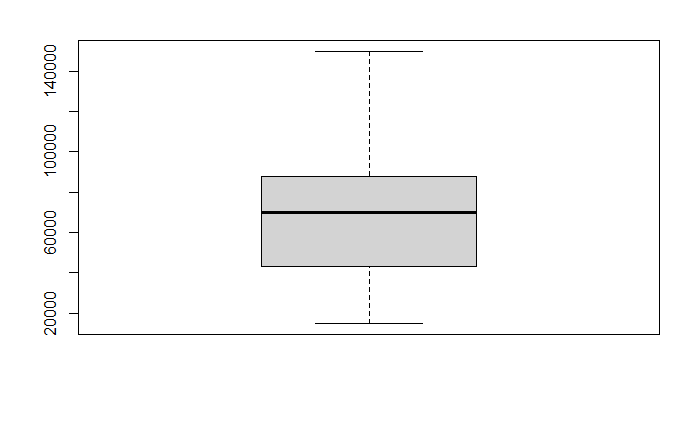

```r
boxplot(df$EstimatedSalary)
```

#### Qualitative features analysis

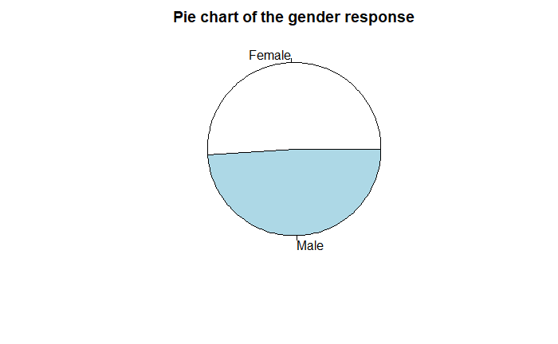

```r
pie(table(df$Gender), main="Pie chart of the gender response")
```

#### Target analysis

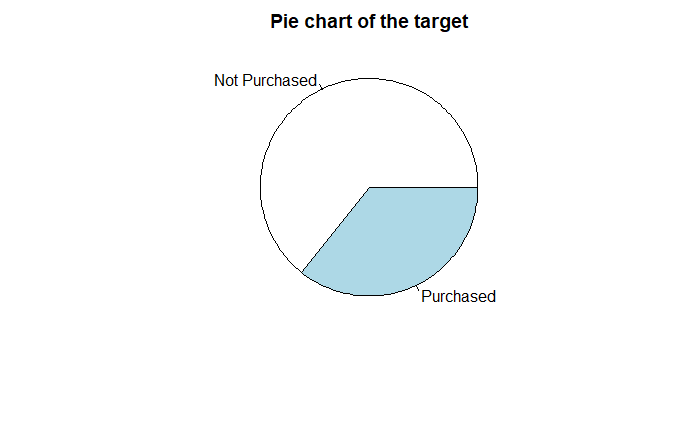

```r
pie(table(df$Purchased), c("Not Purchased", "Purchased"), main="Pie chart of the target")
```

### 3. Now we are going to split the dataset into training set and test set. Last week we did it manually. From now on we will split it randomly, you can use this code (after undestanding it of course):

```r
library(caTools) # install it first in the console
set.seed(123)
# we use the function set.seed() with the same seed number
# to randomly generate the same values, you already know that right?
#and you know why we want to generate the same values, am I wrong?
split = sample.split(df$Purchased, SplitRatio = 0.75)
# here we chose the SplitRatio to 75% of the dataset,
# and 25% for the test set.
training_set = subset(df, split == TRUE)
# we use subset to split the dataset
test_set = subset(df, split == FALSE)
```

### 4. Scale the input variables in both training set and test set. Do you know what is scaling? Explain it one sentence.

```r
training_set$Age = scale(training_set$Age)
training_set$EstimatedSalary = scale(training_set$EstimatedSalary)

test_set$Age = scale(test_set$Age)
test_set$EstimatedSalary = scale(test_set$EstimatedSalary)
```

Scaling is the process of normalizing data.

### 5. Now fit a simple logistic regression model of Purchased in function of Age

```r
model_purchased_age = glm(Purchased ~ Age, data = training_set, family = "binomial")
model_purchased_age
```

```
Call:  glm(formula = Purchased ~ Age, family = "binomial", data = training_set)

Coefficients:
(Intercept)          Age
    -0.9299       1.9913

Degrees of Freedom: 299 Total (i.e. Null);  298 Residual
Null Deviance:      390.9
Residual Deviance: 252.1    AIC: 256.1
```

### 6. As you saw in the Logistic Regression chapter and in the previous question, we choose argument family to be binomial when we use the function glm. Explain why!

glm is the function for generalized linear model, so we need to predict the type (or family) of glm.  
Here we want to predict a binary response so we use the binomial law (a special case for the bernouilli law).

### 7. Write in a equation the model you obtained in question 5?

There are multiples ways to write the logistic function: $F(X)=\frac{1}{1+e^{-(\beta 0+\beta 1X)}}$ $F(X)=\frac{e^{\beta 0+\beta 1X}}{1+e^{\beta 0+\beta 1X}}$

### 8. Is the feature Age significant to the model? Justify your answer.

```r
summary(model_purchased_age)
```

```
Call:
glm(formula = Purchased ~ Age, family = "binomial", data = training_set)

Deviance Residuals:
    Min       1Q   Median       3Q      Max
-2.5341  -0.6641  -0.2950   0.5437   2.4392

Coefficients:
            Estimate Std. Error z value Pr(>|z|)
(Intercept)  -0.9299     0.1672  -5.562 2.67e-08 ***
Age           1.9913     0.2342   8.502  < 2e-16 ***
---
Signif. codes:  0 ‘***’ 0.001 ‘**’ 0.01 ‘*’ 0.05 ‘.’ 0.1 ‘ ’ 1

(Dispersion parameter for binomial family taken to be 1)

    Null deviance: 390.89  on 299  degrees of freedom
Residual deviance: 252.11  on 298  degrees of freedom
AIC: 256.11

Number of Fisher Scoring iterations: 5
```

Let’s check the p value:  
p_value for Age (<2e-16) < 0.05 (5%)  
So we can say that the feature Age is significant for our model

### 9. What is the value of AIC of the model?

AIC = 256.11

```r
typeof(data.frame(Age = x)$Age)
```

```
[1] "double"
```

### 10. Plot Purchased in function of Age and add the curve of the obtained logistic regression model.

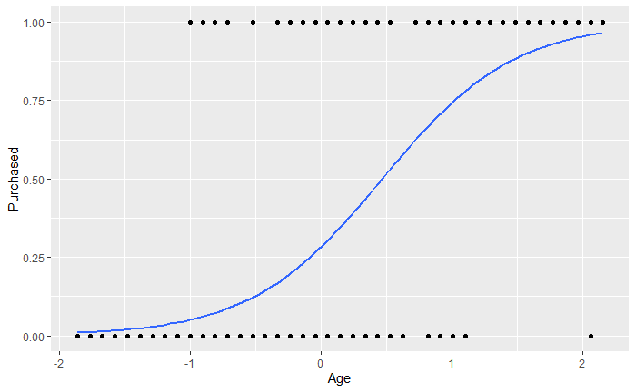

```r
library(ggplot2)
ggplot(model_purchased_age, aes(x=Age, y=Purchased)) +
  geom_point() +
  stat_smooth(method="glm", method.args=list(family="binomial"), se=FALSE)
```

### 11. Now let us take another feature into account in the model. Fit a logistic regression model of purchasing the product in function of the age of a user and its salary.

```r
model_purchased_age_salary = glm(Purchased ~ Age + EstimatedSalary, data = training_set, family = "binomial")
model_purchased_age_salary
```

```
Call:  glm(formula = Purchased ~ Age + EstimatedSalary, family = "binomial",
    data = training_set)

Coefficients:
    (Intercept)              Age  EstimatedSalary
         -1.192            2.632            1.395

Degrees of Freedom: 299 Total (i.e. Null);  297 Residual
Null Deviance:      390.9
Residual Deviance: 199.8    AIC: 205.8
```

### 12. Are the predictors significant to the new model?

```r
summary(model_purchased_age_salary)
```

```
Call:
glm(formula = Purchased ~ Age + EstimatedSalary, family = "binomial",
    data = training_set)

Deviance Residuals:
    Min       1Q   Median       3Q      Max
-3.0753  -0.5235  -0.1161   0.3224   2.3977

Coefficients:
                Estimate Std. Error z value Pr(>|z|)
(Intercept)      -1.1923     0.2018  -5.908 3.47e-09 ***
Age               2.6324     0.3461   7.606 2.83e-14 ***
EstimatedSalary   1.3947     0.2326   5.996 2.03e-09 ***
---
Signif. codes:  0 ‘***’ 0.001 ‘**’ 0.01 ‘*’ 0.05 ‘.’ 0.1 ‘ ’ 1

(Dispersion parameter for binomial family taken to be 1)

    Null deviance: 390.89  on 299  degrees of freedom
Residual deviance: 199.78  on 297  degrees of freedom
AIC: 205.78

Number of Fisher Scoring iterations: 6
```

Let’s check the p value:  
- p_value for Age (2.83e-14) < 0.05 (5%)  
- p_value for EstimatedSalary (2.03e-09) < 0.05 (5%)  
So we can say that the features Age and EstimatedSalary is significant for our model

### 13. Do we obtain a better model by adding the estimated salary?

We can use the AIC criteron to compare model to each others.

AIC with the feature age = 256.11  
AIC with the features age and EstimatedSalary = 205.78  
AIC with the features age and EstimatedSalary < AIC with the feature age

So we obtain a better model by adding the estimated salary

### 14. Predictions: On the test set, predict the probability of purchasing the product by the users using the obtained model.

```r
y_hat_purchased_age_salary = predict(model_purchased_age_salary, newdata = test_set[c("Age","EstimatedSalary")], type="response")
y_hat_purchased_age_salary
```

```
           2            4            5            9           12           18           19           20           22           29           32           34
0.0162395375 0.0117148379 0.0037846461 0.0024527456 0.0073339436 0.2061576580 0.2669935073 0.3851475689 0.5448578778 0.0103005636 0.2994922143 0.0084168787
          35           38           45           46           48           52           66           69           74           75           82           84
0.0494471952 0.0171641479 0.0485051303 0.0008343060 0.0102561619 0.0007055347 0.0058448457 0.0044534947 0.3933468488 0.0071065671 0.1068589185 0.2580084947
          85           86           87           89          103          104          107          108          109          117          124          126
0.0303248927 0.3303649169 0.0051132916 0.0263861849 0.1310148056 0.7649772313 0.0034367786 0.0473827096 0.0327965105 0.1626049288 0.0675494054 0.2189658514
         127          131          134          139          148          154          156          159          162          163          170          175
0.4142562486 0.0324337750 0.0043457839 0.0163538708 0.1030590600 0.0751093248 0.0048556976 0.0027487256 0.0306647902 0.0463555716 0.0122981409 0.1169016711
         176          193          199          200          208          213          224          226          228          229          230          234
0.0011936610 0.0103005636 0.0252589417 0.0177353905 0.9870859806 0.9453359968 0.9969454446 0.1064430571 0.9979393884 0.3705093415 0.5807527959 0.9117762840
         236          237          239          241          255          264          265          266          273          274          281          286
0.7817273411 0.2310672929 0.8037996043 0.9682706714 0.6686007827 0.1451169281 0.9060311409 0.8293112410 0.9568520348 0.6781064291 0.9926955397 0.4170486388
         292          299          302          305          307          310          316          324          326          332          339          341
0.9220096987 0.7363498859 0.8247736816 0.2558136823 0.9932007105 0.1178058928 0.3442845494 0.3958138650 0.3059412440 0.9725035550 0.1431602303 0.9842795480
         343          347          353          363          364          367          368          369          372          373          380          383
0.2073273008 0.9371909698 0.6843940060 0.5559479117 0.5698028861 0.9440512240 0.8427877409 0.2549836305 0.9928717092 0.3243409327 0.8519685008 0.9697473704
         389          392          395          400
0.3793408625 0.2718336775 0.2040229226 0.5236436275
```

### 15. Take a look on your predicted values for the variable Purchased. We predicted the probability that the user will purchase the product right? Now in order to compare your results with the real answers, transform the predicted values to 0 or 1 (1 if >0.5).

```r
y_hat_purchased_age_salary_bin = ifelse(y_hat_purchased_age_salary>0.5,1,0)
y_hat_purchased_age_salary_bin
```

```
  2   4   5   9  12  18  19  20  22  29  32  34  35  38  45  46  48  52  66  69  74  75  82  84  85  86  87  89 103 104 107 108 109 117 124 126 127 131 134 139 148
  0   0   0   0   0   0   0   0   1   0   0   0   0   0   0   0   0   0   0   0   0   0   0   0   0   0   0   0   0   1   0   0   0   0   0   0   0   0   0   0   0
154 156 159 162 163 170 175 176 193 199 200 208 213 224 226 228 229 230 234 236 237 239 241 255 264 265 266 273 274 281 286 292 299 302 305 307 310 316 324 326 332
  0   0   0   0   0   0   0   0   0   0   0   1   1   1   0   1   0   1   1   1   0   1   1   1   0   1   1   1   1   1   0   1   1   1   0   1   0   0   0   0   1
339 341 343 347 353 363 364 367 368 369 372 373 380 383 389 392 395 400
  0   1   0   1   1   1   1   1   1   0   1   0   1   1   0   0   0   1
```

### 16. Now in order to evaluate the model and its predictions, compute the confusion matrix. What do you obtain ?

```r
conf_mat = table(y_hat_purchased_age_salary_bin, test_set$Purchased)
conf_mat
```

```
y_hat_purchased_age_salary_bin  0  1
                             0 57 10
                             1  7 26
```

### 17. Calculate the accuracy, specificity, sensitivity and the precision of the model.

```r
all_metrics<-function(conf_mat){
accuracy = (conf_mat[1] +  conf_mat[4])/sum(conf_mat)
sensitivity = conf_mat[1]/(conf_mat[1] +  conf_mat[2])
specificity = conf_mat[4]/(conf_mat[3] +  conf_mat[4])
precision  = conf_mat[1]/(conf_mat[1] +  conf_mat[3])
return(list(accuracy = accuracy, sensitivity = sensitivity,
            specificity = specificity, precision = precision))
}

all_metrics(conf_mat)
```

```
$accuracy
[1] 0.83

$sensitivity
[1] 0.890625

$specificity
[1] 0.7222222

$precision
[1] 0.8507463
```

### 18. Plot the ROC curve and calculate AUC value.

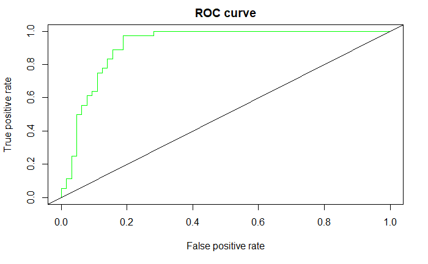

```r
library(ROCR)
preds = prediction(y_hat_purchased_age_salary, test_set$Purchased)

# TPR: True Positive Rate => sensitivity
# FPR: False Positivity Rate => 1 - TNR (True Negative Rate) => specificity
perf = performance(preds,"tpr","fpr")
plot(perf,col="green", main="ROC curve")
abline(0,1)
```

```r
auc = performance(preds, "auc")
auc = auc@y.values[[1]]
auc
```

```
[1] 0.9171007
```

### 19. Compare the AUC of the two models you fitted (one with only age and one with age and estimated salary) and plot their ROC curves in the same figure.

```r
y_hat_purchased_age = predict(model_purchased_age, newdata = test_set[c("Age","EstimatedSalary")], type="response")
y_hat_purchased_age_bin = ifelse(y_hat_purchased_age>0.5,1,0)
y_hat_purchased_age_bin
```

```
  2   4   5   9  12  18  19  20  22  29  32  34  35  38  45  46  48  52  66  69  74  75  82  84  85  86  87  89 103 104 107 108 109 117 124 126 127 131 134 139 148
  0   0   0   0   0   1   1   1   1   0   0   0   0   0   0   0   0   0   0   0   0   0   0   0   0   0   0   0   0   0   0   0   0   0   0   0   0   0   0   0   0
154 156 159 162 163 170 175 176 193 199 200 208 213 224 226 228 229 230 234 236 237 239 241 255 264 265 266 273 274 281 286 292 299 302 305 307 310 316 324 326 332
  0   0   0   0   0   0   0   0   0   0   0   1   1   1   0   1   0   0   1   1   0   1   0   1   0   1   0   1   0   1   0   1   1   1   0   1   0   0   1   0   1
339 341 343 347 353 363 364 367 368 369 372 373 380 383 389 392 395 400
  0   1   0   1   0   1   0   1   1   0   1   0   1   1   1   1   0   1
```

```r
preds_purchased_age = prediction(y_hat_purchased_age, test_set$Purchased)
auc_purchased_age = performance(preds_purchased_age, "auc")
auc_purchased_age = auc_purchased_age@y.values[[1]]
auc_purchased_age
```

```
[1] 0.8823785
```

```r
preds_purchased_age_salary = prediction(y_hat_purchased_age_salary, test_set$Purchased)
auc_purchased_age_salary = performance(preds_purchased_age_salary, "auc")
auc_purchased_age_salary = auc_purchased_age_salary@y.values[[1]]
auc_purchased_age_salary
```

```
[1] 0.9171007
```

```r
preds_purchased_age = prediction(y_hat_purchased_age, test_set$Purchased)
preds_purchased_age_salary = prediction(y_hat_purchased_age_salary, test_set$Purchased)
```

AUC for model with age: 0.8824  
AUC for model with age and EstimatedSalary: 0.9171

```r
perf = performance(preds_purchased_age_salary,"tpr","fpr")
plot(perf,col="blue", main="ROC curves")
perf = performance(preds_purchased_age,"tpr","fpr")
plot(perf,col="red", add=TRUE)
```

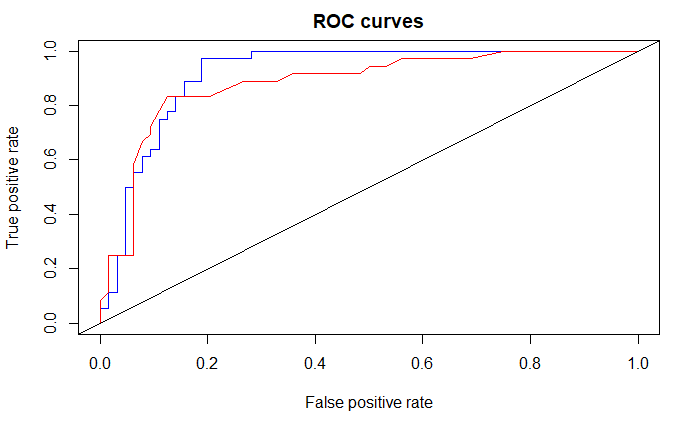

```r
abline(0,1)

legend(1, 95, legend=c("Line 1", "Line 2"),
       col=c("red", "blue"), lty=1:2, cex=0.8)
```